# WHITE WINE DATA ANALYSIS by AKASH PATEL

# Final Plots and Summary

### Plot One

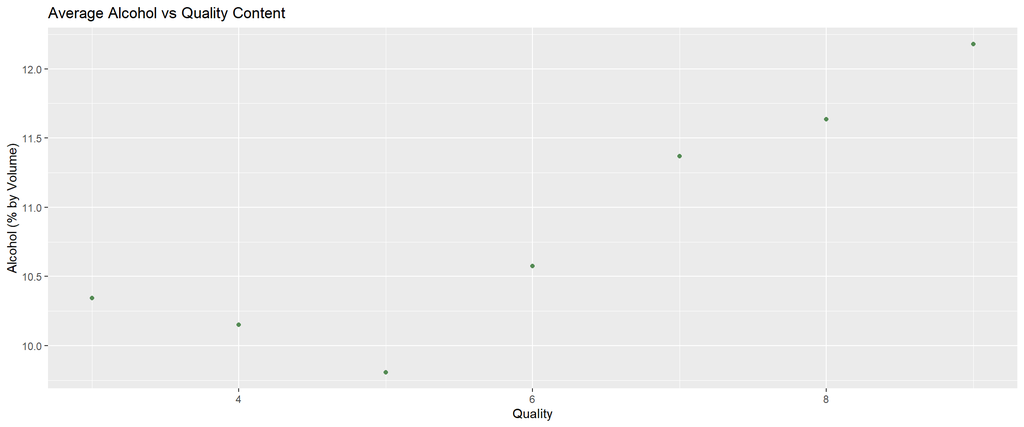

### Plot Two

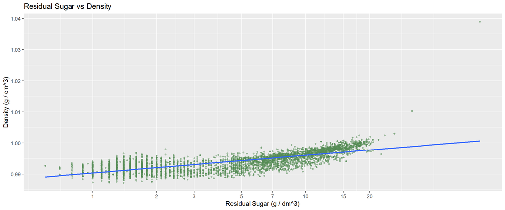

### Description Two

Residual was the most interesting variable because of its high correlation with every other variable in the dataset. As we can see that with density, the relationship with residual sugar is in a linear fashion.

### Plot Three

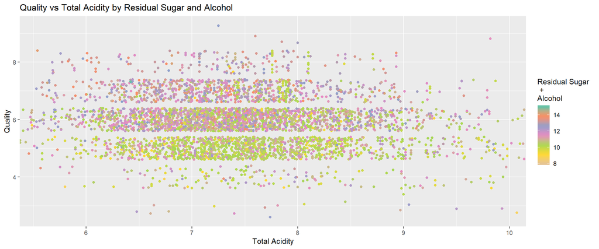

# Reflection

By looking at the final three plots and overall project, we can come to the conclusion that higher quality white wine will have higher alcohol percentage levels, slight less sugar and a lower density than water. Which surpriced me the most was that the residual sugar does not correlate with white wine quality.

What went well for me was that I was very excited to analyze the data straight away without having to worry about cleaning it as it was provided nicely and organized. However, I did have to create a variable, which I hoped was included in the dataset. Nonetheless, I recommend including more wine data, such as color, cost, and origin. Would be very interesting to see if quality correlates to color at all, which would make wine selection much easier.

The project was fun to do, however it took more time than I had anticipated.